# Step 1 — Data Preparation

### Macro indicators over time — what each dummy captures

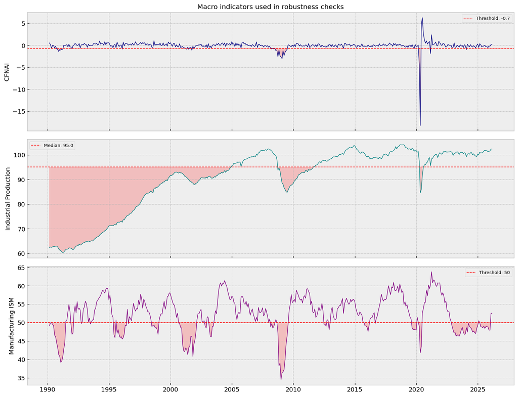

```
  → saved: plots/robustness_macro_indicators.png
```

```python
fig, axes = plt.subplots(3, 1, figsize=(13, 10), sharex=True)

# Panel 1: CFNAI with threshold
ax = axes[0]
ax.plot(df_m.index, df_m['cfnai'], color='navy', linewidth=0.9)
ax.axhline(-0.7, color='red', linewidth=1, linestyle='--', label='Threshold: -0.7')
ax.fill_between(df_m.index, df_m['cfnai'], -0.7,
                where=(df_m['cfnai'] < -0.7), color='red', alpha=0.2)
ax.set_ylabel('CFNAI')
ax.legend(fontsize=8)
ax.set_title('Macro indicators used in robustness checks', fontsize=12)

# Panel 2: IP with median
ax = axes[1]
ax.plot(df_m.index, df_m['ip'], color='teal', linewidth=0.9)
ax.axhline(ip_median, color='red', linewidth=1, linestyle='--',
           label=f'Median: {ip_median:.1f}')
ax.fill_between(df_m.index, df_m['ip'], ip_median,
                where=(df_m['ip'] < ip_median), color='red', alpha=0.2)
ax.set_ylabel('Industrial Production')
ax.legend(fontsize=8)

# Panel 3: ISM with threshold 50
ax = axes[2]
ax.plot(df_m.index, df_m['ism'], color='purple', linewidth=0.9)
ax.axhline(50, color='red', linewidth=1, linestyle='--', label='Threshold: 50')
ax.fill_between(df_m.index, df_m['ism'], 50,
                where=(df_m['ism'] < 50), color='red', alpha=0.2)
ax.set_ylabel('Manufacturing ISM')
ax.legend(fontsize=8)

for ax in axes:
    ax.xaxis.set_major_locator(mdates.YearLocator(5))
    ax.xaxis.set_major_formatter(mdates.DateFormatter('%Y'))

plt.tight_layout()
plt.savefig(os.path.join(PLOTS_DIR, 'robustness_macro_indicators.png'), bbox_inches='tight')
plt.show()
print('  → saved: plots/robustness_macro_indicators.png')
```

## 7. Save all robustness tables

```python
for tag, res_w, res_e in [
    ('ip',    res_ip_world,    res_ip_em),
    ('ism',   res_ism_world,   res_ism_em),
    ('cfnai_cont', res_cfnai_world, res_cfnai_em),
]:
    tbl = pd.DataFrame({
        'World_beta':  res_w['beta'],
        'World_tstat': res_w['t'],
        'EM_beta':     res_e['beta'],
        'EM_tstat':    res_e['t'],
    }, index=res_w['columns'])
    extra = pd.DataFrame({
        'World_beta': [res_w['nobs'], round(res_w['r2'],4)],
        'World_tstat': ['',''],
        'EM_beta': [res_e['nobs'], round(res_e['r2'],4)],
        'EM_tstat': ['','']
    }, index=['N','R²'])
    tbl_full = pd.concat([tbl, extra])
    tbl_full.to_csv(os.path.join(TABLES_DIR, f'robustness_{tag}.csv'))
    save_table(tbl_full, f'robustness_{tag}.png',
               f'Robustness — {tag.upper()} specification')

print('\nAll robustness tables saved.')
```

```
  → saved: tables\robustness_ip.png
  → saved: tables\robustness_ism.png
  → saved: tables\robustness_cfnai_cont.png

All robustness tables saved.
```

## 8. Files saved to `tables/` and `plots/`

| File | Content |
| --- | --- |
| `robustness_ip.csv/png` | Check 1: IP dummy |
| `robustness_ism.csv/png` | Check 2: ISM dummy |
| `robustness_cfnai_cont.csv/png` | Check 3: CFNAI continuous |
| `robustness_interaction_comparison.csv/png` | Side-by-side comparison of interaction coefficient |
| `robustness_interaction_plot.png` | Bar chart comparison |
| `robustness_macro_indicators.png` | CFNAI / IP / ISM time series with thresholds |

# Step 5 — VAR Models & Forecasting

## 0. Setup

```python
from statsmodels.tsa.api import VAR
from statsmodels.stats.diagnostic import acorr_ljungbox

warnings.filterwarnings('ignore')

TABLES_DIR = 'tables'
PLOTS_DIR  = 'plots'
os.makedirs(TABLES_DIR, exist_ok=True)
os.makedirs(PLOTS_DIR,  exist_ok=True)

plt.rcParams['figure.dpi'] = 120
plt.rcParams['font.size'] = 11

# Utility: save a DataFrame as PNG table
def save_table(df_table, filename, title=None):
    """Save a DataFrame as PNG table in tables/ — following step 1 convention."""
    display_df = df_table.copy()
    for col in display_df.columns:
        display_df[col] = display_df[col].apply(
            lambda x: str(int(float(x))) if (isinstance(x, (int, float)) and x != '' and float(x) == int(float(x)) and abs(float(x)) < 1e10)
                      else (f'{float(x):.4f}' if isinstance(x, (int, float)) and x != '' else x)
        )
    fig, ax = plt.subplots(figsize=(max(7, 1.8 * len(df_table.columns)),
                                    max(2, 0.45 * (len(df_table) + 2))))
    ax.axis('off')
    tbl = ax.table(
        cellText=display_df.values,
        rowLabels=display_df.index.tolist(),
        colLabels=display_df.columns.tolist(),
        loc='center', cellLoc='center'
    )
    tbl.auto_set_font_size(False)
    tbl.set_fontsize(9)
    tbl.scale(1, 1.3)
    if title:
        ax.set_title(title, pad=12, fontsize=10)
    plt.tight_layout()
    path = os.path.join(TABLES_DIR, filename)
    fig.savefig(path, dpi=200, bbox_inches='tight')
    plt.close(fig)
    print(f'  → saved: {path}')
```

## 1. Load data

## Section 5 — VAR: Daily Financial Variables

### 5.1 Variable vectors

We estimate two daily VAR systems as specified in the project plan:

$$y_1 = \begin{pmatrix} Oil_t \\ FedRate_t \\ MSCI\ World_t \end{pmatrix} \qquad y_2 = \begin{pmatrix} Oil_t \\ FedRate_t \\ MSCI\ EM_t \end{pmatrix}$$

**Oil is ordered first** so that its contemporaneous shock can affect the other variables in the same period. This is the standard Cholesky identification assumption for oil price shocks.

```python
# y1: Oil, Fed Rate (yield changes), MSCI World
var1_data = df_daily[['roil', 'rrate', 'rworld']].dropna()
var1_data.columns = ['Oil', 'Fed Rate', 'MSCI World']

# y2: Oil, Fed Rate, MSCI EM
var2_data = df_daily[['roil', 'rrate', 'rem']].dropna()
var2_data.columns = ['Oil', 'Fed Rate', 'MSCI EM']

print('VAR y1 (World):', var1_data.shape, '|', var1_data.index[0].date(), 'to', var1_data.index[-1].date())
print('VAR y2 (EM):   ', var2_data.shape)
print()

# Summary statistics
stats = var1_data.describe().T[['mean','std','min','max']].round(4)
display(stats)
stats.to_csv(os.path.join(TABLES_DIR, 'var_daily_summary_stats.csv'))
```

```
VAR y1 (World): (9442, 3) | 1990-01-02 to 2026-03-11
VAR y2 (EM):    (9442, 3)
```

|  | mean | std | min | max |
| --- | --- | --- | --- | --- |
| Oil | 0.0002 | 0.0219 | -0.3856 | 0.1908 |
| Fed Rate | -0.0004 | 0.0583 | -0.4736 | 0.3602 |
| MSCI World | 0.0002 | 0.0094 | -0.1044 | 0.0910 |

### 5.2 Lag selection

We test lag lengths from 1 to 10 days using AIC, BIC, FPE and HQIC information criteria.

- **AIC** tends to select more lags (lower penalty)
- **BIC** is more parsimonious (higher penalty for additional parameters)

```python
print('=== Lag selection: y1 (World) ===')
model1 = VAR(var1_data)
lag_sel1 = model1.select_order(10)

lag_table1 = pd.DataFrame({
    'AIC':  lag_sel1.ics['aic'],
    'BIC':  lag_sel1.ics['bic'],
    'HQIC': lag_sel1.ics['hqic'],
    'FPE':  lag_sel1.ics['fpe'],
})
lag_table1.index.name = 'Lag'

lag_display = lag_table1.copy()
lag_display['FPE'] = lag_table1['FPE'].apply(lambda x: f'{x:.3e}')

print(lag_sel1.summary())
display(lag_display)
lag_table1.to_csv(os.path.join(TABLES_DIR, 'var1_lag_selection.csv'))
save_table(lag_display, 'var1_lag_selection.png', 'Lag selection — y1 (World)')
```

```
=== Lag selection: y1 (World) ===
 VAR Order Selection (* highlights the minimums)
==================================================
       AIC         BIC         FPE         HQIC
--------------------------------------------------
0       -22.75      -22.75   1.315e-10      -22.75
1       -22.77     -22.76*   1.292e-10     -22.77*
2       -22.77      -22.75   1.291e-10      -22.77
3       -22.77      -22.75   1.289e-10      -22.76
4       -22.77      -22.74   1.290e-10      -22.76
5       -22.77      -22.73   1.290e-10      -22.76
6       -22.77      -22.73   1.287e-10      -22.76
7      -22.77*      -22.72  1.286e-10*      -22.76
8       -22.77      -22.72   1.286e-10      -22.75
9       -22.77      -22.71   1.286e-10      -22.75
10      -22.77      -22.70   1.287e-10      -22.75
--------------------------------------------------
```

| Lag | AIC | BIC | HQIC | FPE |
| --- | --- | --- | --- | --- |
| 0 | -22.752011 | -22.749736 | -22.751239 | 1.315e-10 |
| 1 | -22.769477 | -22.760377 | -22.766388 | 1.292e-10 |
| 2 | -22.770791 | -22.754868 | -22.765386 | 1.291e-10 |
| 3 | -22.771927 | -22.749179 | -22.764204 | 1.289e-10 |
| 4 | -22.771558 | -22.741986 | -22.761519 | 1.290e-10 |
| 5 | -22.771074 | -22.734678 | -22.758718 | 1.290e-10 |
| 6 | -22.773783 | -22.730562 | -22.759110 | 1.287e-10 |
| 7 | -22.774426 | -22.724381 | -22.757436 | 1.286e-10 |
| 8 | -22.774144 | -22.717275 | -22.754838 | 1.286e-10 |
| 9 | -22.773960 | -22.710267 | -22.752337 | 1.286e-10 |
| 10 | -22.773588 | -22.703070 | -22.749649 | 1.287e-10 |

```
  → saved: tables\var1_lag_selection.png
```

```python
print('=== Lag selection: y2 (EM) ===')
model2 = VAR(var2_data)
lag_sel2 = model2.select_order(10)

lag_table2 = pd.DataFrame({
    'AIC':  lag_sel2.ics['aic'],
    'BIC':  lag_sel2.ics['bic'],
    'HQIC': lag_sel2.ics['hqic'],
    'FPE':  lag_sel2.ics['fpe'],
})
lag_table2.index.name = 'Lag'

lag_display2 = lag_table2.copy()
lag_display2['FPE'] = lag_table2['FPE'].apply(lambda x: f'{x:.3e}')

print(lag_sel2.summary())
display(lag_display2)
lag_table2.to_csv(os.path.join(TABLES_DIR, 'var2_lag_selection.csv'))
save_table(lag_display2, 'var2_lag_selection.png', 'Lag selection — y2 (EM)')
```

```
=== Lag selection: y2 (EM) ===
 VAR Order Selection (* highlights the minimums)
==================================================
       AIC         BIC         FPE         HQIC
--------------------------------------------------
0       -22.39      -22.39   1.891e-10      -22.39
1       -22.44     -22.43*   1.801e-10     -22.43*
2       -22.44      -22.42   1.800e-10      -22.43
3       -22.44      -22.42   1.798e-10      -22.43
4       -22.44      -22.41   1.800e-10      -22.43
5       -22.44      -22.40   1.801e-10      -22.43
6       -22.44      -22.40   1.796e-10      -22.43
7      -22.44*      -22.39  1.794e-10*      -22.42
8       -22.44      -22.38   1.794e-10      -22.42
9       -22.44      -22.38   1.795e-10      -22.42
10      -22.44      -22.37   1.797e-10      -22.42
--------------------------------------------------
```

| Lag | AIC | BIC | HQIC | FPE |
| --- | --- | --- | --- | --- |
| 0 | -22.388634 | -22.386359 | -22.387862 | 1.891e-10 |
| 1 | -22.437648 | -22.428549 | -22.434559 | 1.801e-10 |
| 2 | -22.438197 | -22.422274 | -22.432791 | 1.800e-10 |
| 3 | -22.439070 | -22.416322 | -22.431347 | 1.798e-10 |
| 4 | -22.438164 | -22.408592 | -22.428125 | 1.800e-10 |
| 5 | -22.437592 | -22.401196 | -22.425236 | 1.801e-10 |
| 6 | -22.440229 | -22.397008 | -22.425556 | 1.796e-10 |
| 7 | -22.441549 | -22.391504 | -22.424560 | 1.794e-10 |
| 8 | -22.441400 | -22.384531 | -22.422094 | 1.794e-10 |
| 9 | -22.440730 | -22.377036 | -22.419107 | 1.795e-10 |
| 10 | -22.439999 | -22.369482 | -22.416060 | 1.797e-10 |

```
  → saved: tables\var2_lag_selection.png
```

### 5.3 Estimation

We estimate each VAR using the lag length selected above. Each equation is estimated by OLS (reduced-form VAR).

```python
p1 = max(1, lag_sel1.bic)
p2 = max(1, lag_sel2.bic)
print(f'Selected lags: y1 (World) = {p1}, y2 (EM) = {p2}')

var1_fit = model1.fit(p1)
var2_fit = model2.fit(p2)

print(var1_fit.summary())
print(var2_fit.summary())
```

```
Selected lags: y1 (World) = 1, y2 (EM) = 1
  Summary of Regression Results
==================================
Model:                         VAR
Method:                        OLS
Date:           Sun, 05, Apr, 2026
Time:                     02:07:12
--------------------------------------------------------------------
No. of Equations:         3.00000    BIC:                   -22.7603
Nobs:                     9441.00    HQIC:                  -22.7663
Log likelihood:           67306.5    FPE:                1.29229e-10
AIC:                     -22.7694    Det(Omega_mle):     1.29065e-10
--------------------------------------------------------------------
Results for equation Oil
================================================================================
                   coefficient       std. error           t-stat            prob
--------------------------------------------------------------------------------
const                 0.000158         0.000225            0.702           0.483
L1.Oil               -0.012356         0.010555           -1.171           0.242
L1.Fed Rate           0.005020         0.003952            1.270           0.204
L1.MSCI World         0.031163         0.024829            1.255           0.209
================================================================================

Results for equation Fed Rate
================================================================================
                   coefficient       std. error           t-stat            prob
--------------------------------------------------------------------------------
const                -0.000319         0.000599           -0.532           0.595
L1.Oil                0.035524         0.028072            1.265           0.206
L1.Fed Rate          -0.006361         0.010510           -0.605           0.545
L1.MSCI World        -0.388662         0.066037           -5.886           0.000
================================================================================

Results for equation MSCI World
================================================================================
                   coefficient       std. error           t-stat            prob
--------------------------------------------------------------------------------
const                 0.000193         0.000096            2.006           0.045
L1.Oil               -0.009970         0.004503           -2.214           0.027
L1.Fed Rate          -0.005824         0.001686           -3.455           0.001
```

[output cut: 43 more lines]

```
Results for equation MSCI EM
==============================================================================
                 coefficient       std. error           t-stat            prob
------------------------------------------------------------------------------
const               0.000162         0.000112            1.449           0.147
L1.Oil              0.012704         0.005207            2.440           0.015
L1.Fed Rate         0.003430         0.001940            1.768           0.077
L1.MSCI EM          0.206636         0.010249           20.161           0.000
==============================================================================

Correlation matrix of residuals
                 Oil  Fed Rate   MSCI EM
Oil         1.000000  0.132082  0.168677
Fed Rate    0.132082  1.000000  0.127910
MSCI EM     0.168677  0.127910  1.000000
```

### 5.4 Granger causality tests

**Granger causality** tests whether past values of oil returns provide statistically significant information to predict current equity returns, beyond what is already in the equity returns' own past.

- **H0**: Oil does NOT Granger-cause equity returns
- If p-value < 0.05: oil has predictive power for equity markets

```python
print('=== Granger causality: y1 (World) ===')
print('Does Oil Granger-cause MSCI World?')
gc1_world = var1_fit.test_causality('MSCI World', ['Oil'], kind='f')
print(gc1_world.summary())

print('\nDoes MSCI World Granger-cause Oil?')
gc1_oil = var1_fit.test_causality('Oil', ['MSCI World'], kind='f')
print(gc1_oil.summary())
```

```
=== Granger causality: y1 (World) ===
Does Oil Granger-cause MSCI World?
Granger causality F-test. H_0: Oil does not Granger-cause MSCI World. Conclusion: reject H_0 at 5% significance level.
================================================
Test statistic Critical value p-value     df
------------------------------------------------
         4.904          3.842   0.027 (1, 28311)
------------------------------------------------

Does MSCI World Granger-cause Oil?
Granger causality F-test. H_0: MSCI World does not Granger-cause Oil. Conclusion: fail to reject H_0 at 5% significance level.
================================================
Test statistic Critical value p-value     df
------------------------------------------------
         1.575          3.842   0.209 (1, 28311)
------------------------------------------------
```

```python
print('=== Granger causality: y2 (EM) ===')
print('Does Oil Granger-cause MSCI EM?')
gc2_em = var2_fit.test_causality('MSCI EM', ['Oil'], kind='f')
print(gc2_em.summary())

print('\nDoes MSCI EM Granger-cause Oil?')
gc2_oil = var2_fit.test_causality('Oil', ['MSCI EM'], kind='f')
print(gc2_oil.summary())
```

```
=== Granger causality: y2 (EM) ===
Does Oil Granger-cause MSCI EM?
Granger causality F-test. H_0: Oil does not Granger-cause MSCI EM. Conclusion: reject H_0 at 5% significance level.
================================================
Test statistic Critical value p-value     df
------------------------------------------------
         5.953          3.842   0.015 (1, 28311)
------------------------------------------------

Does MSCI EM Granger-cause Oil?
Granger causality F-test. H_0: MSCI EM does not Granger-cause Oil. Conclusion: fail to reject H_0 at 5% significance level.
================================================
Test statistic Critical value p-value     df
------------------------------------------------
         3.756          3.842   0.053 (1, 28311)
------------------------------------------------
```

### 5.5 Diagnostics — stability and residual autocorrelation

```python
def var_diagnostics(var_fit, label):
    """
    Two diagnostics:
    1. Stability: all roots have modulus > 1
    2. Residual Ljung-Box test at lag 10
    """
    print(f'\n=== Diagnostics: {label} ===')

    # Stability
    roots = var_fit.roots
    is_stable = np.all(np.abs(roots) > 1)
    print(f'  Stable VAR (all |roots| > 1): {is_stable}')
    print(f'  Min |root|: {np.abs(roots).min():.4f}')

    # Ljung-Box on residuals
    print(f'  Ljung-Box test (lag 10) on residuals:')
    for col in var_fit.resid.columns:
        lb = acorr_ljungbox(var_fit.resid[col].dropna(), lags=[10], return_df=True)
        pval = lb['lb_pvalue'].values[0]
        print(f'    {col:15s}: p-value = {pval:.4f}  {"(autocorr. remains)" if pval < 0.05 else "(OK)"}')

var_diagnostics(var1_fit, 'y1 — World')
var_diagnostics(var2_fit, 'y2 — EM')
```

```
=== Diagnostics: y1 — World ===
  Stable VAR (all |roots| > 1): True
  Min |root|: 7.9089
  Ljung-Box test (lag 10) on residuals:
    Oil            : p-value = 0.0234  (autocorr. remains)
    Fed Rate       : p-value = 0.0004  (autocorr. remains)
    MSCI World     : p-value = 0.0000  (autocorr. remains)

=== Diagnostics: y2 — EM ===
  Stable VAR (all |roots| > 1): True
  Min |root|: 4.8318
  Ljung-Box test (lag 10) on residuals:
    Oil            : p-value = 0.0170  (autocorr. remains)
    Fed Rate       : p-value = 0.0007  (autocorr. remains)
    MSCI EM        : p-value = 0.0000  (autocorr. remains)
```

### 5.6 Impulse Response Functions (IRF)

We study the effect of a **one standard deviation oil price shock** on MSCI World and MSCI EM.

#### Cholesky identification

The reduced-form shocks $u_t$ are correlated. To identify **structural** shocks, we use the **Cholesky decomposition**:

$$\Sigma_u = PP'$$

where $P$ is a lower-triangular matrix. We then define orthogonal shocks $\varepsilon_t$ such that $u_t = P\varepsilon_t$.

Because **Oil is ordered first**, the oil shock $\varepsilon_1$ is identified as the first orthogonalized innovation — it is the part of the oil residual that is orthogonal to nothing (since it comes first). Economically: we assume oil shocks are **exogenous** in the contemporaneous period.

**Confidence bands** are computed by Monte Carlo simulation (300 replications) at the 95% level.

```python
def plot_irf(var_fit, impulse, responses, horizon=20, repl=300, label='', tag=''):
    """
    Plot orthogonalized IRFs with Monte Carlo confidence bands.

    Parameters
    ----------
    var_fit   : fitted VAR from statsmodels
    impulse   : name of the shock variable (e.g. 'Oil')
    responses : list of response variable names
    horizon   : number of periods ahead
    repl      : Monte Carlo replications for confidence bands
    """
    irf = var_fit.irf(horizon)
    lower, upper = irf.errband_mc(orth=True, repl=repl, signif=0.05, seed=42)

    variables = list(var_fit.names)
    impulse_idx = variables.index(impulse)
    horizons = np.arange(horizon + 1)

    fig, axes = plt.subplots(1, len(responses), figsize=(6 * len(responses), 4), sharey=False)
    if len(responses) == 1:
        axes = [axes]

    for ax, resp in zip(axes, responses):
        resp_idx = variables.index(resp)
        irf_vals = irf.orth_irfs[:, resp_idx, impulse_idx]
        lo_vals  = lower[:, resp_idx, impulse_idx]
        hi_vals  = upper[:, resp_idx, impulse_idx]

        ax.plot(horizons, irf_vals, color='steelblue', linewidth=1.5,
                label='IRF')
        ax.fill_between(horizons, lo_vals, hi_vals, alpha=0.2,
                         color='steelblue', label='95% MC band')
        ax.axhline(0, color='black', linewidth=0.8, linestyle='--')
        ax.set_title(f'Response of {resp}\nto 1 s.d. {impulse} shock', fontsize=10)
        ax.set_xlabel('Periods after shock')
        ax.set_ylabel('Response')
        ax.legend(fontsize=8)

    plt.suptitle(f'Orthogonalized IRF — {label}', fontsize=11)
    plt.tight_layout()
    fname = os.path.join(PLOTS_DIR, f'irf_{tag}.png')
    plt.savefig(fname, bbox_inches='tight')
    plt.show()
    print(f'  → saved: {fname}')

print('IRF function ready.')
```

```
IRF function ready.
```

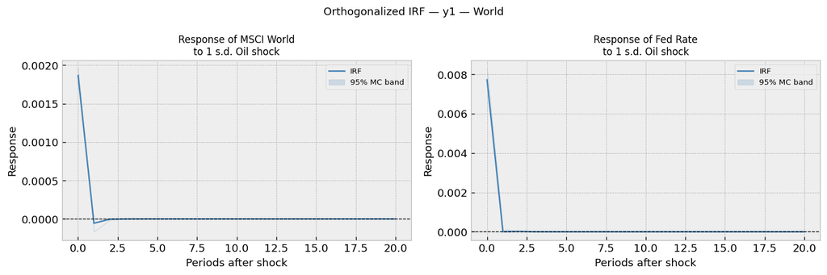

```
  → saved: plots\irf_var1_oil_shock.png
```

```python
# IRF: y1 — response of World and Fed Rate to oil shock
plot_irf(var1_fit, impulse='Oil',
         responses=['MSCI World', 'Fed Rate'],
         horizon=20, repl=300,
         label='y1 — World',
         tag='var1_oil_shock')
```

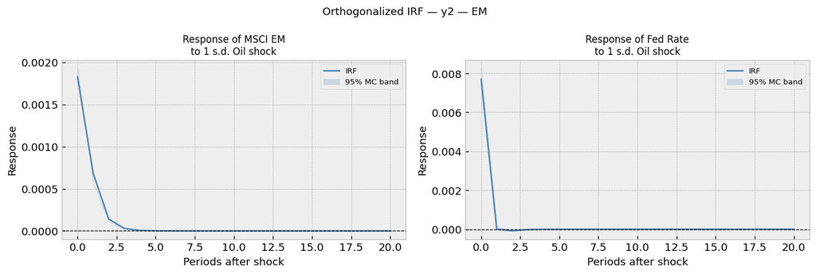

```
  → saved: plots\irf_var2_oil_shock.png
```

```python
# IRF: y2 — response of EM and Fed Rate to oil shock
plot_irf(var2_fit, impulse='Oil',
         responses=['MSCI EM', 'Fed Rate'],
         horizon=20, repl=300,
         label='y2 — EM',
         tag='var2_oil_shock')
```

## Section 6 — VAR: Monthly Macroeconomic Extension

### 6.1 Variable vector

As specified in the project plan:

$$y_3 = \begin{pmatrix} Oil_t \\ Manufacturing\ ISM_t \\ CFNAI_t \end{pmatrix}$$

This system asks: **does oil predict macro activity, and how does macro activity transmit oil shocks?**

```python
# y3: Oil (monthly), ISM, CFNAI
var3_data = df_monthly[['roil_monthly', 'ism', 'cfnai']].dropna()
var3_data.columns = ['Oil', 'ISM', 'CFNAI']

print('VAR y3 (Monthly macro):', var3_data.shape)
print(var3_data.index[0].date(), 'to', var3_data.index[-1].date())
print()
display(var3_data.describe().round(4))
```

```
VAR y3 (Monthly macro): (434, 3)
1990-01-31 to 2026-02-28
```

|  | Oil | ISM | CFNAI |
| --- | --- | --- | --- |
| count | 434.0000 | 434.0000 | 434.0000 |
| mean | 0.0030 | 52.2048 | -0.0733 |
| std | 0.0926 | 4.8842 | 1.1138 |
| min | -0.6339 | 34.5000 | -18.2600 |
| 25% | -0.0461 | 49.0000 | -0.2875 |
| 50% | 0.0077 | 52.5500 | 0.0100 |
| 75% | 0.0607 | 55.7000 | 0.2400 |
| max | 0.3660 | 63.8000 | 6.3000 |

### 6.2 Lag selection

```python
model3 = VAR(var3_data)
lag_sel3 = model3.select_order(12)

lag_table3 = pd.DataFrame({
    'AIC':  lag_sel3.ics['aic'],
    'BIC':  lag_sel3.ics['bic'],
    'HQIC': lag_sel3.ics['hqic'],
    'FPE':  lag_sel3.ics['fpe'],
})
lag_table3.index.name = 'Lag'

print(lag_sel3.summary())
display(lag_table3.round(4))
lag_table3.to_csv(os.path.join(TABLES_DIR, 'var3_lag_selection.csv'))
save_table(lag_table3.round(4), 'var3_lag_selection.png', 'Lag selection — y3 (Monthly macro)')
```

```
 VAR Order Selection (* highlights the minimums)
==================================================
       AIC         BIC         FPE         HQIC
--------------------------------------------------
0       -1.587      -1.558      0.2046      -1.575
1       -3.868     -3.753*     0.02089     -3.823*
2      -3.878*      -3.676    0.02070*      -3.798
3       -3.850      -3.563     0.02128      -3.737
4       -3.862      -3.488     0.02103      -3.714
5       -3.826      -3.366     0.02179      -3.645
6       -3.816      -3.270     0.02202      -3.600
7       -3.807      -3.174     0.02222      -3.557
8       -3.772      -3.053     0.02301      -3.488
9       -3.744      -2.939     0.02368      -3.426
10      -3.756      -2.865     0.02339      -3.404
11      -3.742      -2.764     0.02373      -3.356
12      -3.750      -2.686     0.02356      -3.329
--------------------------------------------------
```

| Lag | AIC | BIC | HQIC | FPE |
| --- | --- | --- | --- | --- |
| 0 | -1.5866 | -1.5578 | -1.5752 | 0.2046 |
| 1 | -3.8685 | -3.7534 | -3.8230 | 0.0209 |
| 2 | -3.8777 | -3.6765 | -3.7982 | 0.0207 |
| 3 | -3.8502 | -3.5627 | -3.7366 | 0.0213 |
| 4 | -3.8619 | -3.4881 | -3.7142 | 0.0210 |
| 5 | -3.8264 | -3.3663 | -3.6445 | 0.0218 |
| 6 | -3.8162 | -3.2698 | -3.6003 | 0.0220 |
| 7 | -3.8069 | -3.1742 | -3.5569 | 0.0222 |
| 8 | -3.7721 | -3.0532 | -3.4881 | 0.0230 |
| 9 | -3.7438 | -2.9387 | -3.4257 | 0.0237 |
| 10 | -3.7561 | -2.8646 | -3.4038 | 0.0234 |
| 11 | -3.7420 | -2.7643 | -3.3557 | 0.0237 |
| 12 | -3.7497 | -2.6858 | -3.3293 | 0.0236 |

```
  → saved: tables\var3_lag_selection.png
```

### 6.3 Estimation

```python
p3 = max(1, lag_sel3.bic)
print(f'Selected lag (BIC): {p3}')

var3_fit = model3.fit(p3)
print(var3_fit.summary())
```

```
Selected lag (BIC): 1
  Summary of Regression Results
==================================
Model:                         VAR
Method:                        OLS
Date:           Sun, 05, Apr, 2026
Time:                     02:07:35
--------------------------------------------------------------------
No. of Equations:         3.00000    BIC:                   -3.69190
Nobs:                     433.000    HQIC:                  -3.76018
Log likelihood:          -1007.48    FPE:                  0.0222657
AIC:                     -3.80471    Det(Omega_mle):       0.0216598
--------------------------------------------------------------------
Results for equation Oil
===========================================================================
              coefficient       std. error           t-stat            prob
---------------------------------------------------------------------------
const           -0.096344         0.050167           -1.920           0.055
L1.Oil           0.196428         0.047857            4.104           0.000
L1.ISM           0.001880         0.000956            1.967           0.049
L1.CFNAI        -0.009311         0.004176           -2.230           0.026
===========================================================================

Results for equation ISM
===========================================================================
              coefficient       std. error           t-stat            prob
---------------------------------------------------------------------------
const            5.454646         0.952370            5.727           0.000
L1.Oil           4.671475         0.908531            5.142           0.000
L1.ISM           0.895825         0.018144           49.374           0.000
L1.CFNAI         0.241033         0.079278            3.040           0.002
===========================================================================

Results for equation CFNAI
===========================================================================
              coefficient       std. error           t-stat            prob
---------------------------------------------------------------------------
const           -1.885663         0.555572           -3.394           0.001
L1.Oil           4.440862         0.529998            8.379           0.000
L1.ISM           0.034574         0.010584            3.267           0.001
L1.CFNAI         0.068798         0.046248            1.488           0.137
===========================================================================

Correlation matrix of residuals
              Oil       ISM     CFNAI
Oil      1.000000  0.199062  0.068845
ISM      0.199062  1.000000  0.270083
CFNAI    0.068845  0.270083  1.000000
```

### 6.4 Granger causality

```python
print('=== Granger causality: y3 (Monthly macro) ===')
print('Does Oil Granger-cause ISM?')
print(var3_fit.test_causality('ISM', ['Oil'], kind='f').summary())

print('\nDoes Oil Granger-cause CFNAI?')
print(var3_fit.test_causality('CFNAI', ['Oil'], kind='f').summary())

print('\nDoes ISM Granger-cause CFNAI?')
print(var3_fit.test_causality('CFNAI', ['ISM'], kind='f').summary())
```

```
=== Granger causality: y3 (Monthly macro) ===
Does Oil Granger-cause ISM?
Granger causality F-test. H_0: Oil does not Granger-cause ISM. Conclusion: reject H_0 at 5% significance level.
===============================================
Test statistic Critical value p-value     df
-----------------------------------------------
         26.44          3.849   0.000 (1, 1287)
-----------------------------------------------

Does Oil Granger-cause CFNAI?
Granger causality F-test. H_0: Oil does not Granger-cause CFNAI. Conclusion: reject H_0 at 5% significance level.
===============================================
Test statistic Critical value p-value     df
-----------------------------------------------
         70.21          3.849   0.000 (1, 1287)
-----------------------------------------------

Does ISM Granger-cause CFNAI?
Granger causality F-test. H_0: ISM does not Granger-cause CFNAI. Conclusion: reject H_0 at 5% significance level.
===============================================
Test statistic Critical value p-value     df
-----------------------------------------------
         10.67          3.849   0.001 (1, 1287)
-----------------------------------------------
```

### 6.5 Diagnostics

```python
var_diagnostics(var3_fit, 'y3 — Monthly macro')
```

```
=== Diagnostics: y3 — Monthly macro ===
  Stable VAR (all |roots| > 1): True
  Min |root|: 1.0903
  Ljung-Box test (lag 10) on residuals:
    Oil            : p-value = 0.1285  (OK)
    ISM            : p-value = 0.2948  (OK)
    CFNAI          : p-value = 0.0145  (autocorr. remains)
```

### 6.6 IRF — monthly macro

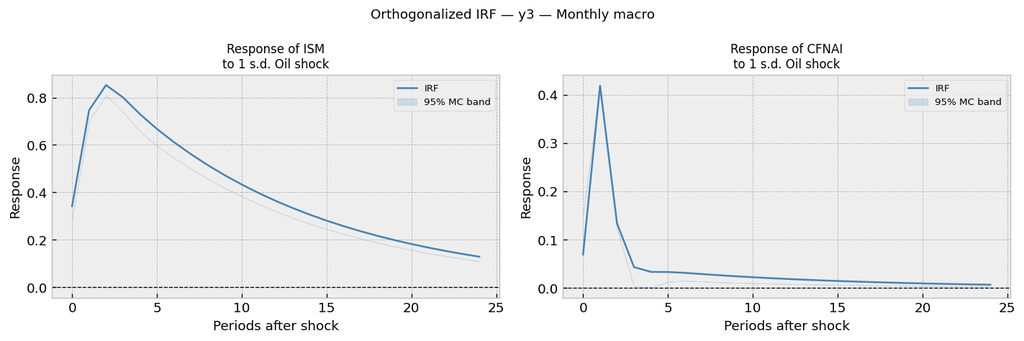

```
  → saved: plots\irf_var3_oil_shock_macro.png
```

```python
# Response of ISM and CFNAI to oil shock (monthly, 24 months horizon)
plot_irf(var3_fit, impulse='Oil',
         responses=['ISM', 'CFNAI'],
         horizon=24, repl=300,
         label='y3 — Monthly macro',
         tag='var3_oil_shock_macro')
```

## Section 7 — Forecasting

### 7.1 Setup

We follow the **train/test split** from the project plan:

- **Train**: 1990 – 2015 (estimation window)
- **Test**: 2016 – end of sample (out-of-sample prediction)

We estimate the VAR on the training sample only, then forecast the test period and evaluate with **RMSE** (Root Mean Squared Error):

$$RMSE = \sqrt{\frac{1}{H} \sum_{h=1}^{H} (y_{T+h} - \hat{y}_{T+h})^2}$$

```python
TRAIN_END = '2015-12-31'
TEST_START = '2016-01-01'

# Daily VAR (y1: World)
train_d = var1_data.loc[:TRAIN_END]
test_d  = var1_data.loc[TEST_START:]

print(f'Daily train: {train_d.index[0].date()} to {train_d.index[-1].date()} ({len(train_d)} obs)')
print(f'Daily test : {test_d.index[0].date()}  to {test_d.index[-1].date()}  ({len(test_d)} obs)')
print()

# Monthly VAR (y3: macro)
train_m = var3_data.loc[:TRAIN_END]
test_m  = var3_data.loc[TEST_START:]

print(f'Monthly train: {train_m.index[0].date()} to {train_m.index[-1].date()} ({len(train_m)} obs)')
print(f'Monthly test : {test_m.index[0].date()}  to {test_m.index[-1].date()}  ({len(test_m)} obs)')
```

```
Daily train: 1990-01-02 to 2015-12-31 (6783 obs)
Daily test : 2016-01-01  to 2026-03-11  (2659 obs)

Monthly train: 1990-01-31 to 2015-12-31 (312 obs)
Monthly test : 2016-01-31  to 2026-02-28  (122 obs)
```

### 7.2 Daily VAR forecast (y1 — World)

```python
# Re-estimate y1 on training sample only
var1_train = VAR(train_d).fit(p1)

# Multi-step out-of-sample forecast using the last p1 observations from the training sample
forecast_vals1 = var1_train.forecast(train_d.values[-p1:], steps=len(test_d))
forecast_df1   = pd.DataFrame(forecast_vals1, index=test_d.index, columns=var1_data.columns)

# RMSE per variable
errors1 = test_d - forecast_df1
rmse1   = pd.DataFrame(np.sqrt((errors1 ** 2).mean()), columns=['RMSE'])

display(rmse1.round(4))
rmse1.to_csv(os.path.join(TABLES_DIR, 'forecast_rmse_daily_world.csv'))
save_table(rmse1.round(4), 'forecast_rmse_daily_world.png', 'RMSE — Daily VAR y1 (World)')
```

|  | RMSE |
| --- | --- |
| Oil | 0.0236 |
| Fed Rate | 0.0532 |
| MSCI World | 0.0095 |

```
  → saved: tables\forecast_rmse_daily_world.png
```

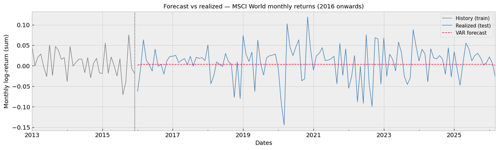

```
  → saved: plots/forecast_world_vs_realized.png
```

```python
# Plot: forecast vs realized for MSCI World (monthly aggregation for readability)
forecast_m_world = forecast_df1['MSCI World'].resample('ME').sum()
actual_m_world   = test_d['MSCI World'].resample('ME').sum()
train_m_world    = train_d['MSCI World'].resample('ME').sum()

fig, ax = plt.subplots(figsize=(13, 4))
train_m_world.loc['2013':].plot(ax=ax, color='gray', linewidth=1, label='History (train)')
actual_m_world.plot(ax=ax, color='steelblue', linewidth=1, label='Realized (test)')
forecast_m_world.plot(ax=ax, color='crimson', linewidth=1, linestyle='--',
                      label='VAR forecast')
ax.axvline(pd.Timestamp(TRAIN_END), color='black', linewidth=1, linestyle=':')
ax.set_title('Forecast vs realized — MSCI World monthly returns (2016 onwards)', fontsize=11)
ax.set_ylabel('Monthly log-return (sum)')
ax.legend(fontsize=9)
plt.tight_layout()
plt.savefig(os.path.join(PLOTS_DIR, 'forecast_world_vs_realized.png'), bbox_inches='tight')
plt.show()
print('  → saved: plots/forecast_world_vs_realized.png')
```

### 7.3 Monthly VAR forecast (y3 — macro)

```python
var3_train = VAR(train_m).fit(p3)

forecast_vals3 = var3_train.forecast(train_m.values[-p3:], steps=len(test_m))
forecast_df3   = pd.DataFrame(forecast_vals3, index=test_m.index, columns=var3_data.columns)

errors3 = test_m - forecast_df3
rmse3   = pd.DataFrame(np.sqrt((errors3 ** 2).mean()), columns=['RMSE'])

display(rmse3.round(4))
rmse3.to_csv(os.path.join(TABLES_DIR, 'forecast_rmse_monthly_macro.csv'))
save_table(rmse3.round(4), 'forecast_rmse_monthly_macro.png', 'RMSE — Monthly VAR y3 (Macro)')
```

|  | RMSE |
| --- | --- |
| Oil | 0.1019 |
| ISM | 5.2502 |
| CFNAI | 1.9126 |

```
  → saved: tables\forecast_rmse_monthly_macro.png
```

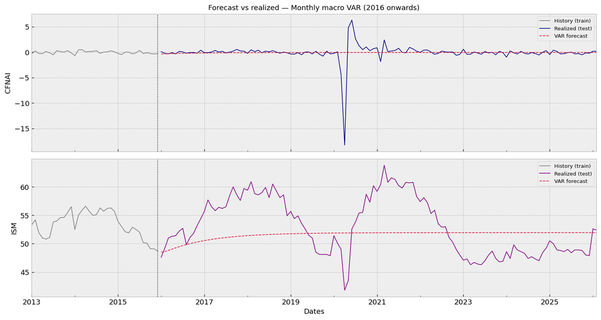

```
  → saved: plots/forecast_macro_vs_realized.png
```

```python
# Plot: forecast vs realized for CFNAI and ISM
fig, axes = plt.subplots(2, 1, figsize=(13, 7), sharex=True)

for ax, var, color in zip(axes, ['CFNAI', 'ISM'], ['navy', 'purple']):
    train_m[var].loc['2013':].plot(ax=ax, color='gray', linewidth=1, label='History (train)')
    test_m[var].plot(ax=ax, color=color, linewidth=1, label='Realized (test)')
    forecast_df3[var].plot(ax=ax, color='crimson', linewidth=1, linestyle='--', label='VAR forecast')
    ax.axvline(pd.Timestamp(TRAIN_END), color='black', linewidth=1, linestyle=':')
    ax.set_ylabel(var)
    ax.legend(fontsize=8)

axes[0].set_title('Forecast vs realized — Monthly macro VAR (2016 onwards)', fontsize=11)
plt.tight_layout()
plt.savefig(os.path.join(PLOTS_DIR, 'forecast_macro_vs_realized.png'), bbox_inches='tight')
plt.show()
print('  → saved: plots/forecast_macro_vs_realized.png')
```

### 7.4 RMSE comparison summary

```python
# Consolidate RMSE results
rmse_all = pd.concat([rmse1.rename(columns={'RMSE':'RMSE_daily_y1'}),
                      rmse3.rename(columns={'RMSE':'RMSE_monthly_y3'})], axis=0)

rmse_all.to_csv(os.path.join(TABLES_DIR, 'forecast_rmse_all.csv'))

print('RMSE summary:')
display(rmse_all.round(5))

print()
# Daily financial VAR
std_world = var1_data['MSCI World'].std()
rmse_world = rmse1.loc['MSCI World', 'RMSE']
print(f"MSCI World daily std = {std_world:.4f}")
print(f"MSCI World daily RMSE = {rmse_world:.4f}")
print(f"RMSE/std ratio = {rmse_world / std_world:.2f}")

# Monthly macro VAR
std_ism = var3_data['ISM'].std()
std_cfnai = var3_data['CFNAI'].std()
rmse_ism = rmse3.loc['ISM', 'RMSE']
rmse_cfnai = rmse3.loc['CFNAI', 'RMSE']

print()
print(f"ISM monthly std = {std_ism:.4f}, RMSE = {rmse_ism:.4f}, ratio = {rmse_ism / std_ism:.2f}")
print(f"CFNAI monthly std = {std_cfnai:.4f}, RMSE = {rmse_cfnai:.4f}, ratio = {rmse_cfnai / std_cfnai:.2f}")
```

```
RMSE summary:
```

|  | RMSE_daily_y1 | RMSE_monthly_y3 |
| --- | --- | --- |
| Oil | 0.02365 | NaN |
| Fed Rate | 0.05318 | NaN |
| MSCI World | 0.00952 | NaN |
| Oil | NaN | 0.10193 |
| ISM | NaN | 5.25023 |
| CFNAI | NaN | 1.91260 |

```
MSCI World daily std = 0.0094
MSCI World daily RMSE = 0.0095
RMSE/std ratio = 1.01

ISM monthly std = 4.8842, RMSE = 5.2502, ratio = 1.07
CFNAI monthly std = 1.1138, RMSE = 1.9126, ratio = 1.72
```

## 8. Files saved to `tables/` and `plots/`

| File | Content |
| --- | --- |
| `var_daily_summary_stats.csv` | Summary stats for VAR variables |
| `var1_lag_selection.csv/png` | Lag selection y1 (World) |
| `var2_lag_selection.csv/png` | Lag selection y2 (EM) |
| `var3_lag_selection.csv/png` | Lag selection y3 (Monthly macro) |
| `irf_var1_oil_shock.png` | IRF: oil shock → World + Fed Rate |
| `irf_var2_oil_shock.png` | IRF: oil shock → EM + Fed Rate |
| `irf_var3_oil_shock_macro.png` | IRF: oil shock → ISM + CFNAI |
| `forecast_rmse_daily_world.csv/png` | RMSE daily y1 (2016–end) |
| `forecast_rmse_monthly_macro.csv/png` | RMSE monthly y3 (2016–end) |
| `forecast_rmse_all.csv` | Consolidated RMSE |
| `forecast_world_vs_realized.png` | Forecast plot — MSCI World |
| `forecast_macro_vs_realized.png` | Forecast plot — CFNAI + ISM |

# Step 6 — VAR Robustness Check

### Robustness Check 1 — Sensitivity to Lag Length

A key modelling choice in VAR estimation is the selection of the lag length (p). This choice involves a trade-off: a small number of lags may omit relevant dynamics (underfitting), while too many lags may introduce noise and reduce estimation efficiency (overfitting).

To assess whether our results are sensitive to this modelling choice, we re-estimate the VAR using the lag length selected by AIC. We then compare the key outputs across specifications, including:

- Granger causality results
- Model diagnostics
- Impulse Response Functions (IRFs)

This robustness check allows us to evaluate whether the main conclusions are driven by the chosen lag structure or remain stable under a less parsimonious specification.

## 0. Set Up

## 1. Load data

## Section 5 — VAR: Daily Financial Variables

### 5.1 Variable vectors

We estimate two daily VAR systems as specified in the project plan:

$$y_1 = \begin{pmatrix} Oil_t \\ FedRate_t \\ MSCI\ World_t \end{pmatrix} \qquad y_2 = \begin{pmatrix} Oil_t \\ FedRate_t \\ MSCI\ EM_t \end{pmatrix}$$

**Oil is ordered first** so that its contemporaneous shock can affect the other variables in the same period. This is the standard Cholesky identification assumption for oil price shocks.

```python
# y1: Oil, Fed Rate (yield changes), MSCI World
var1_data = df_daily[['roil', 'rrate', 'rworld']].dropna()
var1_data.columns = ['Oil', 'Fed Rate', 'MSCI World']

# y2: Oil, Fed Rate, MSCI EM
var2_data = df_daily[['roil', 'rrate', 'rem']].dropna()
var2_data.columns = ['Oil', 'Fed Rate', 'MSCI EM']

print('VAR y1 (World):', var1_data.shape, '|', var1_data.index[0].date(), 'to', var1_data.index[-1].date())
print('VAR y2 (EM):   ', var2_data.shape)
print()

# Summary statistics
stats = var1_data.describe().T[['mean','std','min','max']].round(4)
display(stats)
stats.to_csv(os.path.join(TABLES_DIR, 'var_daily_summary_stats.csv'))
```

```
VAR y1 (World): (9442, 3) | 1990-01-02 to 2026-03-11
VAR y2 (EM):    (9442, 3)
```

|  | mean | std | min | max |
| --- | --- | --- | --- | --- |
| Oil | 0.0002 | 0.0219 | -0.3856 | 0.1908 |
| Fed Rate | -0.0004 | 0.0583 | -0.4736 | 0.3602 |
| MSCI World | 0.0002 | 0.0094 | -0.1044 | 0.0910 |

### 5.2 Lag selection

We test lag lengths from 1 to 10 days using AIC, BIC, FPE, and HQIC information criteria.

- **AIC** tends to select more lags (lower penalty)
- **BIC** is more parsimonious (higher penalty for additional parameters)

```python
print('=== Lag selection: y1 (World) ===')
model1 = VAR(var1_data)
lag_sel1 = model1.select_order(10)

lag_table1 = pd.DataFrame({
    'AIC':  lag_sel1.ics['aic'],
    'BIC':  lag_sel1.ics['bic'],
    'HQIC': lag_sel1.ics['hqic'],
    'FPE':  lag_sel1.ics['fpe'],
})
lag_table1.index.name = 'Lag'

lag_display = lag_table1.copy()
lag_display['FPE'] = lag_table1['FPE'].apply(lambda x: f'{x:.3e}')

print(lag_sel1.summary())
display(lag_display)
lag_table1.to_csv(os.path.join(TABLES_DIR, 'var1_lag_selection.csv'))
save_table(lag_display, 'var1_lag_selection.png', 'Lag selection — y1 (World)')
```

```
=== Lag selection: y1 (World) ===
 VAR Order Selection (* highlights the minimums)
==================================================
       AIC         BIC         FPE         HQIC
--------------------------------------------------
0       -22.75      -22.75   1.315e-10      -22.75
1       -22.77     -22.76*   1.292e-10     -22.77*
2       -22.77      -22.75   1.291e-10      -22.77
3       -22.77      -22.75   1.289e-10      -22.76
4       -22.77      -22.74   1.290e-10      -22.76
5       -22.77      -22.73   1.290e-10      -22.76
6       -22.77      -22.73   1.287e-10      -22.76
7      -22.77*      -22.72  1.286e-10*      -22.76
8       -22.77      -22.72   1.286e-10      -22.75
9       -22.77      -22.71   1.286e-10      -22.75
10      -22.77      -22.70   1.287e-10      -22.75
--------------------------------------------------
```

| Lag | AIC | BIC | HQIC | FPE |
| --- | --- | --- | --- | --- |
| 0 | -22.752011 | -22.749736 | -22.751239 | 1.315e-10 |
| 1 | -22.769477 | -22.760377 | -22.766388 | 1.292e-10 |
| 2 | -22.770791 | -22.754868 | -22.765386 | 1.291e-10 |
| 3 | -22.771927 | -22.749179 | -22.764204 | 1.289e-10 |
| 4 | -22.771558 | -22.741986 | -22.761519 | 1.290e-10 |
| 5 | -22.771074 | -22.734678 | -22.758718 | 1.290e-10 |
| 6 | -22.773783 | -22.730562 | -22.759110 | 1.287e-10 |
| 7 | -22.774426 | -22.724381 | -22.757436 | 1.286e-10 |
| 8 | -22.774144 | -22.717275 | -22.754838 | 1.286e-10 |
| 9 | -22.773960 | -22.710267 | -22.752337 | 1.286e-10 |
| 10 | -22.773588 | -22.703070 | -22.749649 | 1.287e-10 |

```
  → saved: tables\var1_lag_selection.png
```

```python
print('=== Lag selection: y2 (EM) ===')
model2 = VAR(var2_data)
lag_sel2 = model2.select_order(10)

lag_table2 = pd.DataFrame({
    'AIC':  lag_sel2.ics['aic'],
    'BIC':  lag_sel2.ics['bic'],
    'HQIC': lag_sel2.ics['hqic'],
    'FPE':  lag_sel2.ics['fpe'],
})
lag_table2.index.name = 'Lag'

lag_display2 = lag_table2.copy()
lag_display2['FPE'] = lag_table2['FPE'].apply(lambda x: f'{x:.3e}')

print(lag_sel2.summary())
display(lag_display2)
lag_table2.to_csv(os.path.join(TABLES_DIR, 'var2_lag_selection.csv'))
save_table(lag_display2, 'var2_lag_selection.png', 'Lag selection — y2 (EM)')
```

```
=== Lag selection: y2 (EM) ===
 VAR Order Selection (* highlights the minimums)
==================================================
       AIC         BIC         FPE         HQIC
--------------------------------------------------
0       -22.39      -22.39   1.891e-10      -22.39
1       -22.44     -22.43*   1.801e-10     -22.43*
2       -22.44      -22.42   1.800e-10      -22.43
3       -22.44      -22.42   1.798e-10      -22.43
4       -22.44      -22.41   1.800e-10      -22.43
5       -22.44      -22.40   1.801e-10      -22.43
6       -22.44      -22.40   1.796e-10      -22.43
7      -22.44*      -22.39  1.794e-10*      -22.42
8       -22.44      -22.38   1.794e-10      -22.42
9       -22.44      -22.38   1.795e-10      -22.42
10      -22.44      -22.37   1.797e-10      -22.42
--------------------------------------------------
```

| Lag | AIC | BIC | HQIC | FPE |
| --- | --- | --- | --- | --- |
| 0 | -22.388634 | -22.386359 | -22.387862 | 1.891e-10 |
| 1 | -22.437648 | -22.428549 | -22.434559 | 1.801e-10 |
| 2 | -22.438197 | -22.422274 | -22.432791 | 1.800e-10 |
| 3 | -22.439070 | -22.416322 | -22.431347 | 1.798e-10 |
| 4 | -22.438164 | -22.408592 | -22.428125 | 1.800e-10 |
| 5 | -22.437592 | -22.401196 | -22.425236 | 1.801e-10 |
| 6 | -22.440229 | -22.397008 | -22.425556 | 1.796e-10 |
| 7 | -22.441549 | -22.391504 | -22.424560 | 1.794e-10 |
| 8 | -22.441400 | -22.384531 | -22.422094 | 1.794e-10 |
| 9 | -22.440730 | -22.377036 | -22.419107 | 1.795e-10 |
| 10 | -22.439999 | -22.369482 | -22.416060 | 1.797e-10 |

```
  → saved: tables\var2_lag_selection.png
```

### 5.3 Estimation

Using AIC

```python
p1_rb = max(1, lag_sel1.aic)
p2_rb = max(1, lag_sel2.aic)

print(f'Selected lags: y1 (World) = {p1_rb}, y2 (EM) = {p2_rb}')

var1_fit_rb = model1.fit(p1_rb)
var2_fit_rb = model2.fit(p2_rb)

print(var1_fit_rb.summary())
print(var2_fit_rb.summary())
```

```
Selected lags: y1 (World) = 7, y2 (EM) = 7
  Summary of Regression Results
==================================
Model:                         VAR
Method:                        OLS
Date:           Sun, 05, Apr, 2026
Time:                     02:07:40
--------------------------------------------------------------------
No. of Equations:         3.00000    BIC:                   -22.7242
Nobs:                     9435.00    HQIC:                  -22.7572
Log likelihood:           67340.3    FPE:                1.28612e-10
AIC:                     -22.7742    Det(Omega_mle):     1.27716e-10
--------------------------------------------------------------------
Results for equation Oil
================================================================================
                   coefficient       std. error           t-stat            prob
--------------------------------------------------------------------------------
const                 0.000137         0.000225            0.607           0.544
L1.Oil               -0.014988         0.010574           -1.417           0.156
L1.Fed Rate           0.006043         0.003964            1.524           0.127
L1.MSCI World         0.032633         0.025064            1.302           0.193
L2.Oil               -0.033218         0.010590           -3.137           0.002
L2.Fed Rate           0.002453         0.003968            0.618           0.536
L2.MSCI World         0.038334         0.025254            1.518           0.129
L3.Oil               -0.025555         0.010601           -2.411           0.016
L3.Fed Rate           0.000470         0.003969            0.118           0.906
L3.MSCI World         0.033215         0.025258            1.315           0.189
L4.Oil               -0.000032         0.010616           -0.003           0.998
L4.Fed Rate           0.006666         0.003970            1.679           0.093
L4.MSCI World         0.057730         0.025269            2.285           0.022
L5.Oil               -0.007170         0.010613           -0.676           0.499
L5.Fed Rate           0.002950         0.003970            0.743           0.457
L5.MSCI World        -0.025580         0.025254           -1.013           0.311
L6.Oil               -0.021028         0.010605           -1.983           0.047
L6.Fed Rate           0.003796         0.003968            0.956           0.339
L6.MSCI World         0.039245         0.025247            1.554           0.120
L7.Oil                0.005957         0.010610            0.561           0.575
L7.Fed Rate           0.002420         0.003955            0.612           0.541
L7.MSCI World         0.068608         0.025110            2.732           0.006
================================================================================
```

[output cut: 151 more lines]

```
L5.Fed Rate         0.001004         0.001941            0.517           0.605
L5.MSCI EM          0.011084         0.010741            1.032           0.302
L6.Oil             -0.011099         0.005223           -2.125           0.034
L6.Fed Rate        -0.001532         0.001940           -0.790           0.430
L6.MSCI EM         -0.058944         0.010746           -5.485           0.000
L7.Oil              0.002269         0.005225            0.434           0.664
L7.Fed Rate         0.003765         0.001938            1.943           0.052
L7.MSCI EM          0.037368         0.010505            3.557           0.000
==============================================================================

Correlation matrix of residuals
                 Oil  Fed Rate   MSCI EM
Oil         1.000000  0.133561  0.168922
Fed Rate    0.133561  1.000000  0.128039
MSCI EM     0.168922  0.128039  1.000000
```

### 5.4 Granger causality tests

**Granger causality** tests whether past values of oil returns provide statistically significant information to predict current equity returns, beyond what is already in the equity returns' own past.

- **H0**: Oil does NOT Granger-cause equity returns
- If p-value < 0.05: oil has predictive power for equity markets

```python
print('=== Granger causality: y1 (World) ===')
print('Does Oil Granger-cause MSCI World?')
gc1_world = var1_fit_rb.test_causality('MSCI World', ['Oil'], kind='f')
print(gc1_world.summary())

print('\nDoes MSCI World Granger-cause Oil?')
gc1_oil = var1_fit_rb.test_causality('Oil', ['MSCI World'], kind='f')
print(gc1_oil.summary())
```

```
=== Granger causality: y1 (World) ===
Does Oil Granger-cause MSCI World?
Granger causality F-test. H_0: Oil does not Granger-cause MSCI World. Conclusion: reject H_0 at 5% significance level.
==========================================================
Test statistic Critical value p-value          df
----------------------------------------------------------
         3.977          2.010   0.000 (7, np.int64(28239))
----------------------------------------------------------

Does MSCI World Granger-cause Oil?
Granger causality F-test. H_0: MSCI World does not Granger-cause Oil. Conclusion: reject H_0 at 5% significance level.
==========================================================
Test statistic Critical value p-value          df
----------------------------------------------------------
         3.277          2.010   0.002 (7, np.int64(28239))
----------------------------------------------------------
```

```python
print('=== Granger causality: y2 (EM) ===')
print('Does Oil Granger-cause MSCI EM?')
gc2_em = var2_fit_rb.test_causality('MSCI EM', ['Oil'], kind='f')
print(gc2_em.summary())

print('\nDoes MSCI EM Granger-cause Oil?')
gc2_oil = var2_fit_rb.test_causality('Oil', ['MSCI EM'], kind='f')
print(gc2_oil.summary())
```

```
=== Granger causality: y2 (EM) ===
Does Oil Granger-cause MSCI EM?
Granger causality F-test. H_0: Oil does not Granger-cause MSCI EM. Conclusion: reject H_0 at 5% significance level.
==========================================================
Test statistic Critical value p-value          df
----------------------------------------------------------
         2.886          2.010   0.005 (7, np.int64(28239))
----------------------------------------------------------

Does MSCI EM Granger-cause Oil?
Granger causality F-test. H_0: MSCI EM does not Granger-cause Oil. Conclusion: reject H_0 at 5% significance level.
==========================================================
Test statistic Critical value p-value          df
----------------------------------------------------------
         2.147          2.010   0.036 (7, np.int64(28239))
----------------------------------------------------------
```

### 5.6 Impulse Response Functions (IRF)

We study the effect of a **one standard deviation oil price shock** on MSCI World and MSCI EM.

#### Cholesky identification

The reduced-form shocks $u_t$ are correlated. To identify **structural** shocks, we use the **Cholesky decomposition**:

$$\Sigma_u = PP'$$

where $P$ is a lower-triangular matrix. We then define orthogonal shocks $\varepsilon_t$ such that $u_t = P\varepsilon_t$.

Because **Oil is ordered first**, the oil shock $\varepsilon_1$ is identified as the first orthogonalized innovation — it is the part of the oil residual that is orthogonal to nothing (since it comes first). Economically: we assume oil shocks are **exogenous** in the contemporaneous period.

**Confidence bands** are computed by Monte Carlo simulation (300 replications) at the 95% level.

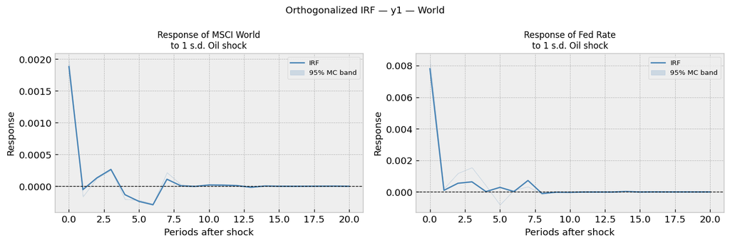

```
  → saved: plots\irf_var1_rb_oil_shock.png
```

```python
# IRF: y1 — response of World and Fed Rate to oil shock
plot_irf(var1_fit_rb, impulse='Oil',
         responses=['MSCI World', 'Fed Rate'],
         horizon=20, repl=300,
         label='y1 — World',
         tag='var1_rb_oil_shock')
```

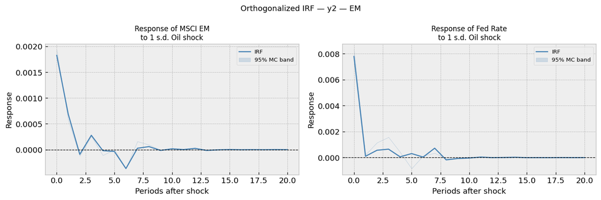

```
  → saved: plots\irf_var2_rb_oil_shock.png
```

```python
# IRF: y2 — response of EM and Fed Rate to oil shock
plot_irf(var2_fit_rb, impulse='Oil',
         responses=['MSCI EM', 'Fed Rate'],
         horizon=20, repl=300,
         label='y2 — EM',
         tag='var2_rb_oil_shock')
```

## Section 6 — VAR: Monthly Macroeconomic Extension

### 6.1 Variable vector

As specified in the project plan:

$$y_3 = \begin{pmatrix} Oil_t \\ Manufacturing\ ISM_t \\ CFNAI_t \end{pmatrix}$$

This system asks: **does oil predict macro activity, and how does macro activity transmit oil shocks?**

```python
# y3: Oil (monthly), ISM, CFNAI
var3_data = df_monthly[['roil_monthly', 'ism', 'cfnai']].dropna()
var3_data.columns = ['Oil', 'ISM', 'CFNAI']

print('VAR y3 (Monthly macro):', var3_data.shape)
print(var3_data.index[0].date(), 'to', var3_data.index[-1].date())
print()
display(var3_data.describe().round(4))
```

```
VAR y3 (Monthly macro): (434, 3)
1990-01-31 to 2026-02-28
```

|  | Oil | ISM | CFNAI |
| --- | --- | --- | --- |
| count | 434.0000 | 434.0000 | 434.0000 |
| mean | 0.0030 | 52.2048 | -0.0733 |
| std | 0.0926 | 4.8842 | 1.1138 |
| min | -0.6339 | 34.5000 | -18.2600 |
| 25% | -0.0461 | 49.0000 | -0.2875 |
| 50% | 0.0077 | 52.5500 | 0.0100 |
| 75% | 0.0607 | 55.7000 | 0.2400 |
| max | 0.3660 | 63.8000 | 6.3000 |

### 6.2 Lag selection

```python
model3 = VAR(var3_data)
lag_sel3 = model3.select_order(12)

lag_table3 = pd.DataFrame({
    'AIC':  lag_sel3.ics['aic'],
    'BIC':  lag_sel3.ics['bic'],
    'HQIC': lag_sel3.ics['hqic'],
    'FPE':  lag_sel3.ics['fpe'],
})
lag_table3.index.name = 'Lag'

print(lag_sel3.summary())
display(lag_table3.round(4))
lag_table3.to_csv(os.path.join(TABLES_DIR, 'var3_lag_selection.csv'))
save_table(lag_table3.round(4), 'var3_lag_selection.png', 'Lag selection — y3 (Monthly macro)')
```

```
 VAR Order Selection (* highlights the minimums)
==================================================
       AIC         BIC         FPE         HQIC
--------------------------------------------------
0       -1.587      -1.558      0.2046      -1.575
1       -3.868     -3.753*     0.02089     -3.823*
2      -3.878*      -3.676    0.02070*      -3.798
3       -3.850      -3.563     0.02128      -3.737
4       -3.862      -3.488     0.02103      -3.714
5       -3.826      -3.366     0.02179      -3.645
6       -3.816      -3.270     0.02202      -3.600
7       -3.807      -3.174     0.02222      -3.557
8       -3.772      -3.053     0.02301      -3.488
9       -3.744      -2.939     0.02368      -3.426
10      -3.756      -2.865     0.02339      -3.404
11      -3.742      -2.764     0.02373      -3.356
12      -3.750      -2.686     0.02356      -3.329
--------------------------------------------------
```

| Lag | AIC | BIC | HQIC | FPE |
| --- | --- | --- | --- | --- |
| 0 | -1.5866 | -1.5578 | -1.5752 | 0.2046 |
| 1 | -3.8685 | -3.7534 | -3.8230 | 0.0209 |
| 2 | -3.8777 | -3.6765 | -3.7982 | 0.0207 |
| 3 | -3.8502 | -3.5627 | -3.7366 | 0.0213 |
| 4 | -3.8619 | -3.4881 | -3.7142 | 0.0210 |
| 5 | -3.8264 | -3.3663 | -3.6445 | 0.0218 |
| 6 | -3.8162 | -3.2698 | -3.6003 | 0.0220 |
| 7 | -3.8069 | -3.1742 | -3.5569 | 0.0222 |
| 8 | -3.7721 | -3.0532 | -3.4881 | 0.0230 |
| 9 | -3.7438 | -2.9387 | -3.4257 | 0.0237 |
| 10 | -3.7561 | -2.8646 | -3.4038 | 0.0234 |
| 11 | -3.7420 | -2.7643 | -3.3557 | 0.0237 |
| 12 | -3.7497 | -2.6858 | -3.3293 | 0.0236 |

```
  → saved: tables\var3_lag_selection.png
```

### 6.3 Estimation

```python
p3_rb = max(1, lag_sel3.aic)
print(f'Selected lag (AIC): {p3_rb}')

var3_fit_rb = model3.fit(p3_rb)
print(var3_fit_rb.summary())
```

```
Selected lag (AIC): 2
  Summary of Regression Results
==================================
Model:                         VAR
Method:                        OLS
Date:           Sun, 05, Apr, 2026
Time:                     02:09:21
--------------------------------------------------------------------
No. of Equations:         3.00000    BIC:                   -3.61331
Nobs:                     432.000    HQIC:                  -3.73300
Log likelihood:          -994.751    FPE:                  0.0221245
AIC:                     -3.81108    Det(Omega_mle):       0.0210829
--------------------------------------------------------------------
Results for equation Oil
===========================================================================
              coefficient       std. error           t-stat            prob
---------------------------------------------------------------------------
const           -0.106933         0.053970           -1.981           0.048
L1.Oil           0.186306         0.049230            3.784           0.000
L1.ISM           0.006852         0.002687            2.550           0.011
L1.CFNAI        -0.009249         0.004524           -2.044           0.041
L2.Oil          -0.059620         0.052615           -1.133           0.257
L2.ISM          -0.004771         0.002541           -1.877           0.060
L2.CFNAI        -0.002589         0.004259           -0.608           0.543
===========================================================================

Results for equation ISM
===========================================================================
              coefficient       std. error           t-stat            prob
---------------------------------------------------------------------------
const            4.455825         1.021588            4.362           0.000
L1.Oil           4.414878         0.931863            4.738           0.000
L1.ISM           0.917566         0.050865           18.039           0.000
L1.CFNAI         0.263649         0.085635            3.079           0.002
L2.Oil          -0.399800         0.995938           -0.401           0.688
L2.ISM          -0.002902         0.048099           -0.060           0.952
L2.CFNAI        -0.203640         0.080624           -2.526           0.012
===========================================================================

Results for equation CFNAI
===========================================================================
              coefficient       std. error           t-stat            prob
---------------------------------------------------------------------------
const           -2.746733         0.589961           -4.656           0.000
L1.Oil           4.244952         0.538145            7.888           0.000
L1.ISM           0.056519         0.029374            1.924           0.054
L1.CFNAI         0.094323         0.049454            1.907           0.056
L2.Oil          -0.591015         0.575148           -1.028           0.304
L2.ISM          -0.005665         0.027777           -0.204           0.838
L2.CFNAI        -0.173825         0.046560           -3.733           0.000
===========================================================================

Correlation matrix of residuals
              Oil       ISM     CFNAI
Oil      1.000000  0.196954  0.061669
ISM      0.196954  1.000000  0.252074
CFNAI    0.061669  0.252074  1.000000
```

### 6.4 Granger causality

```python
print('=== Granger causality: y3_rb (Monthly macro) ===')
print('Does Oil Granger-cause ISM?')
print(var3_fit_rb.test_causality('ISM', ['Oil'], kind='f').summary())

print('\nDoes Oil Granger-cause CFNAI?')
print(var3_fit_rb.test_causality('CFNAI', ['Oil'], kind='f').summary())

print('\nDoes ISM Granger-cause CFNAI?')
print(var3_fit_rb.test_causality('CFNAI', ['ISM'], kind='f').summary())
```

```
=== Granger causality: y3_rb (Monthly macro) ===
Does Oil Granger-cause ISM?
Granger causality F-test. H_0: Oil does not Granger-cause ISM. Conclusion: reject H_0 at 5% significance level.
=========================================================
Test statistic Critical value p-value          df
---------------------------------------------------------
         11.25          3.003   0.000 (2, np.int64(1275))
---------------------------------------------------------

Does Oil Granger-cause CFNAI?
Granger causality F-test. H_0: Oil does not Granger-cause CFNAI. Conclusion: reject H_0 at 5% significance level.
=========================================================
Test statistic Critical value p-value          df
---------------------------------------------------------
         31.11          3.003   0.000 (2, np.int64(1275))
---------------------------------------------------------

Does ISM Granger-cause CFNAI?
Granger causality F-test. H_0: ISM does not Granger-cause CFNAI. Conclusion: reject H_0 at 5% significance level.
=========================================================
Test statistic Critical value p-value          df
---------------------------------------------------------
         10.36          3.003   0.000 (2, np.int64(1275))
---------------------------------------------------------
```

### 6.5 Diagnostics

```python
var_diagnostics(var3_fit_rb, 'y3_rb — Monthly macro')
```

```
=== Diagnostics: y3_rb — Monthly macro ===
  Stable VAR (all |roots| > 1): True
  Min |root|: 1.0848
  Ljung-Box test (lag 10) on residuals:
    Oil            : p-value = 0.2238  (OK)
    ISM            : p-value = 0.2892  (OK)
    CFNAI          : p-value = 0.4438  (OK)
```

### 6.6 IRF — monthly macro

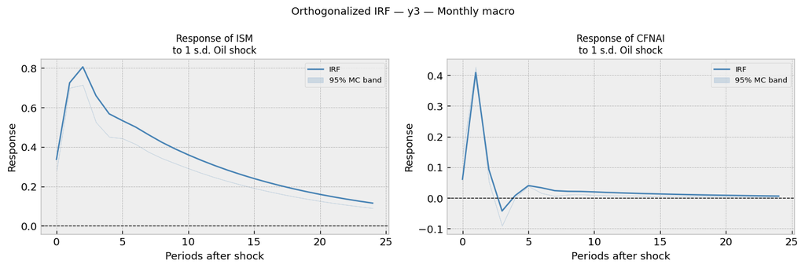

```
  → saved: plots\irf_var3_rb_oil_shock_macro.png
```

```python
# Response of ISM and CFNAI to oil shock (monthly, 24 months horizon)
plot_irf(var3_fit_rb, impulse='Oil',
         responses=['ISM', 'CFNAI'],
         horizon=24, repl=300,
         label='y3 — Monthly macro',
         tag='var3_rb_oil_shock_macro')
```